# EPF - Electricity Spot Price Forecasting

February 10, 2023  
@mzaffran

The aim of this notebook is to introduce some basic notions and tools from machine learning in order to forecast electricity spot prices (a time series) in a supervised approach.  
To do so, one has to deal with some pre-processing, data analysis, choice of a (or multiple) model(s), and the optimization of hyper-parameters.  
We look for accurate forecasting models but also for models able to generalize on unobserved data.

Let's denote the price at time $t$ $Y_t$.
Assume we have some explanatory variables, $d$, in some $X_t$. $X_t$ contains $d$ columns, one for each variable. We assume the following model: $$ Y_t = f(X_t) + \varepsilon_t$$ where $\varepsilon_t$ is stationary.
We aim at finding the best $\hat{f}$ such that: $$ Y_t = \hat{f}(X_t) + \hat{\varepsilon}_t$$ where $\hat{\varepsilon}_t$ is stationary.

# Table of Contents

1. Data preparation
   1. Data investigation
   2. Split the data before learning anything
2. Exploratory Data Analysis
3. Forecasting last semester of 2019
   1. Tools
   2. Optimize hyper-parameters
   3. Evaluation
   4. Forecast last semester
4. Adding useful features!
   1. Lagged price
   2. Lagged price w.r.t. weekdays/weekends
5. Can we forecast 2020? 2021?
   1. 2020
   2. 2021
      1. Growing window

References

We start by some basics imports.

```python
import pandas as pd
import numpy as np
import matplotlib.pyplot as plt
import seaborn as sns
from datetime import datetime
```

```python
url = "https://raw.githubusercontent.com/mzaffran/mzaffran.github.io/master/assets/files/Dauphine/Data_2018_2021.csv"
data = pd.read_csv(url)
```

# Data preparation

Back to table of contents.

## Data investigation

**Q1** Print the dimension of the dataframe data.

**Q2** Show the first 10 and last 10 row of data.

**Q3** Show the list of the columns names.

*Tips: use Pandas commands, such as shape, head, and tail*

```python
data.shape
```

```
(35064, 32)
```

```python
data.head(10)
```

|  | date | FR_SpotPrice | FR_Load | FR_Biomass | FR_Fossil_Gas | FR_Fossil_Hard_coal | FR_Fossil_Oil | FR_Hydro_Pumped_Storage | FR_Hydro_Run-of-river_and_poundage | FR_Hydro_Water_Reservoir | ... | Export_FR_ES | Export_FR_GB | Export_FR_IT_North | Export_FR_DE | ES_SpotPrice | BE_SpotPrice | CH_SpotPrice | IT_SpotPrice | UK_SpotPrice | DE_SpotPrice |
| --- | --- | --- | --- | --- | --- | --- | --- | --- | --- | --- | --- | --- | --- | --- | --- | --- | --- | --- | --- | --- | --- |
| 0 | 2018-01-01 00:00:00 | 4.74 | 56036.0 | 293.0 | 2316.0 | 11.0 | 214.0 | -1343.0 | 5786.0 | 2160.0 | ... | -675.18 | -1409.0 | -516 | 0.0 | 4.74 | 4.74 | 31.08 | 44.16 | 47.14 | -29.99 |
| 1 | 2018-01-01 01:00:00 | 3.66 | 54494.0 | 293.0 | 2286.0 | 11.0 | 215.0 | -1394.0 | 5593.0 | 1571.0 | ... | -548.63 | -1410.0 | -258 | 0.0 | 3.66 | 3.66 | 29.17 | 42.24 | 54.60 | -56.65 |
| 2 | 2018-01-01 02:00:00 | 1.26 | 51574.0 | 294.0 | 2290.0 | 11.0 | 214.0 | -1344.0 | 5507.0 | 1319.0 | ... | -2727.06 | -1316.0 | -207 | 0.0 | 2.30 | 1.26 | 21.96 | 39.29 | 46.63 | -63.14 |
| 3 | 2018-01-01 03:00:00 | -20.10 | 49370.0 | 294.0 | 2291.0 | 10.0 | 215.0 | -1840.0 | 5261.0 | 705.0 | ... | -2787.70 | -1318.0 | -210 | 0.0 | 2.30 | -20.10 | 14.96 | 36.00 | 39.90 | -64.62 |
| 4 | 2018-01-01 04:00:00 | -31.82 | 49000.0 | 294.0 | 2271.0 | 10.0 | 217.0 | -2527.0 | 5233.0 | 482.0 | ... | -2802.13 | -1318.0 | 0 | 0.0 | 2.06 | -31.82 | -5.92 | 41.99 | 23.41 | -67.00 |
| 5 | 2018-01-01 05:00:00 | -28.66 | 49333.0 | 294.0 | 2275.0 | 11.0 | 217.0 | -2830.0 | 5345.0 | 750.0 | ... | -2779.69 | -1318.0 | 0 | 0.0 | 2.06 | -28.66 | -6.10 | 42.25 | 23.61 | -72.54 |
| 6 | 2018-01-01 06:00:00 | -13.71 | 49528.0 | 294.0 | 2393.0 | 11.0 | 216.0 | -2777.0 | 5462.0 | 918.0 | ... | -2565.37 | -1319.0 | 0 | 0.0 | 2.06 | -13.71 | -10.02 | 44.97 | 29.96 | -76.01 |
| 7 | 2018-01-01 07:00:00 | -4.14 | 49360.0 | 294.0 | 2414.0 | 10.0 | 215.0 | -2757.0 | 5504.0 | 1372.0 | ... | -2796.37 | -821.0 | -38 | 0.0 | 2.30 | -19.33 | -5.71 | 45.00 | 24.09 | -71.45 |
| 8 | 2018-01-01 08:00:00 | 2.03 | 50058.0 | 294.0 | 2412.0 | 11.0 | 214.0 | -2596.0 | 5764.0 | 1253.0 | ... | -2517.68 | -710.0 | -112 | 0.0 | 2.30 | -15.78 | -1.88 | 44.94 | 24.14 | -66.88 |
| 9 | 2018-01-01 09:00:00 | -15.51 | 51855.0 | 293.0 | 2408.0 | 11.0 | 214.0 | -2975.0 | 5718.0 | 756.0 | ... | -2739.49 | -1315.0 | 0 | 0.0 | 2.30 | -12.05 | -10.48 | 45.04 | 42.00 | -62.00 |

10 rows × 32 columns

```python
data.tail(10)
```

|  | date | FR_SpotPrice | FR_Load | FR_Biomass | FR_Fossil_Gas | FR_Fossil_Hard_coal | FR_Fossil_Oil | FR_Hydro_Pumped_Storage | FR_Hydro_Run-of-river_and_poundage | FR_Hydro_Water_Reservoir | ... | Export_FR_ES | Export_FR_GB | Export_FR_IT_North | Export_FR_DE | ES_SpotPrice | BE_SpotPrice | CH_SpotPrice | IT_SpotPrice | UK_SpotPrice | DE_SpotPrice |
| --- | --- | --- | --- | --- | --- | --- | --- | --- | --- | --- | --- | --- | --- | --- | --- | --- | --- | --- | --- | --- | --- |
| 35054 | 2021-12-31 14:00:00 | 141.00 | 51480.0 | 372.0 | 2774.0 | 28.0 | 182.0 | -2533.0 | 5848.0 | 2180.0 | ... | -756.24 | -849.0 | -2483 | -716.46 | 141.00 | -8.47 | 154.16 | 190.11 | NaN | 20.49 |
| 35055 | 2021-12-31 15:00:00 | 156.17 | 51046.0 | 368.0 | 2866.0 | 28.0 | 182.0 | -1989.0 | 5868.0 | 2179.0 | ... | -1291.54 | -1019.0 | -2209 | -389.17 | 156.17 | 92.24 | 155.04 | 215.85 | NaN | 62.23 |
| 35056 | 2021-12-31 16:00:00 | 186.03 | 54246.0 | 370.0 | 3128.0 | 28.0 | 181.0 | 727.0 | 6102.0 | 2058.0 | ... | -1374.36 | -863.0 | -2338 | -248.43 | 186.03 | 92.99 | 156.99 | 233.93 | NaN | 60.97 |
| 35057 | 2021-12-31 17:00:00 | 193.15 | 57040.0 | 369.0 | 3247.0 | 28.0 | 691.0 | 2536.0 | 6512.0 | 2519.0 | ... | -2814.19 | -356.0 | -2586 | -364.86 | 193.15 | 78.16 | 176.31 | 221.76 | NaN | 40.01 |
| 35058 | 2021-12-31 18:00:00 | 175.94 | 56693.0 | 368.0 | 3170.0 | 28.0 | 576.0 | 2550.0 | 6567.0 | 2434.0 | ... | -3503.00 | -53.0 | -2676 | -431.22 | 187.95 | 60.72 | 173.95 | 219.14 | NaN | 32.49 |
| 35059 | 2021-12-31 19:00:00 | 157.92 | 54155.0 | 368.0 | 3091.0 | 28.0 | 299.0 | 1889.0 | 6360.0 | 2076.0 | ... | -3517.16 | 0.0 | -2720 | -774.85 | 182.30 | -32.27 | 160.42 | 213.60 | NaN | 0.18 |
| 35060 | 2021-12-31 20:00:00 | 175.12 | 51945.0 | 370.0 | 3074.0 | 27.0 | 182.0 | 596.0 | 6299.0 | 1762.0 | ... | -3078.53 | 0.0 | -2643 | -1181.60 | 175.12 | 6.20 | 158.08 | 192.79 | NaN | 0.08 |
| 35061 | 2021-12-31 21:00:00 | 140.38 | 52907.0 | 368.0 | 2858.0 | 28.0 | 182.0 | -467.0 | 6266.0 | 1740.0 | ... | -1930.41 | 0.0 | -2298 | -440.87 | 140.38 | 35.96 | 155.35 | 180.00 | NaN | 5.10 |
| 35062 | 2021-12-31 22:00:00 | 127.81 | 54542.0 | 369.0 | 2844.0 | 28.0 | 182.0 | 430.0 | 6219.0 | 1658.0 | ... | -1904.79 | 0.0 | -1941 | -400.09 | 127.81 | 36.34 | 150.03 | 180.00 | NaN | 6.32 |
| 35063 | 2021-12-31 23:00:00 | 89.06 | 54542.0 | 373.0 | 2642.0 | 28.0 | 203.0 | 1077.0 | 5863.0 | 2190.0 | ... | -3363.50 | 0.0 | -1757 | -27.76 | 145.86 | 82.02 | 119.97 | 170.28 | NaN | 50.05 |

10 rows × 32 columns

```python
data.columns
```

```
Index(['date', 'FR_SpotPrice', 'FR_Load', 'FR_Biomass', 'FR_Fossil_Gas',
       'FR_Fossil_Hard_coal', 'FR_Fossil_Oil', 'FR_Hydro_Pumped_Storage',
       'FR_Hydro_Run-of-river_and_poundage', 'FR_Hydro_Water_Reservoir',
       'FR_Nuclear', 'FR_Solar', 'FR_Waste', 'FR_Wind_Onshore', 'Import_FR_BE',
       'Import_FR_CH', 'Import_FR_ES', 'Import_FR_GB', 'Import_FR_IT_North',
       'Import_FR_DE', 'Export_FR_BE', 'Export_FR_CH', 'Export_FR_ES',
       'Export_FR_GB', 'Export_FR_IT_North', 'Export_FR_DE', 'ES_SpotPrice',
       'BE_SpotPrice', 'CH_SpotPrice', 'IT_SpotPrice', 'UK_SpotPrice',
       'DE_SpotPrice'],
      dtype='object')
```

**Q4** Analyze the *date* column. What do you think of its format? Is it adequate?

```python
data.date
```

```
0        2018-01-01 00:00:00
1        2018-01-01 01:00:00
2        2018-01-01 02:00:00
3        2018-01-01 03:00:00
4        2018-01-01 04:00:00
                ...
35059    2021-12-31 19:00:00
35060    2021-12-31 20:00:00
35061    2021-12-31 21:00:00
35062    2021-12-31 22:00:00
35063    2021-12-31 23:00:00
Name: date, Length: 35064, dtype: object
```

```python
type(data.date[0])
```

```
str
```

```python
data['date'] = pd.to_datetime(data.date, format = "%Y-%m-%d %H:%M:%S")
```

```python
data.date
```

```
0       2018-01-01 00:00:00
1       2018-01-01 01:00:00
2       2018-01-01 02:00:00
3       2018-01-01 03:00:00
4       2018-01-01 04:00:00
                ...
35059   2021-12-31 19:00:00
35060   2021-12-31 20:00:00
35061   2021-12-31 21:00:00
35062   2021-12-31 22:00:00
35063   2021-12-31 23:00:00
Name: date, Length: 35064, dtype: datetime64[ns]
```

NaN values have to be taken huge care of. In this practical session, we will not focus on an adequate treatment since it is not the aim. Nevertheless, we will have to impute these values! This will be done after splitting the data set: we can not use the target / future values to impute to the old ones!

**Q5** Report the number of non-a-number (NaN) values for each columns.

```python
data.isnull().sum()
```

```
date                                     0
FR_SpotPrice                             0
FR_Load                                 42
FR_Biomass                              24
FR_Fossil_Gas                           24
FR_Fossil_Hard_coal                     24
FR_Fossil_Oil                           24
FR_Hydro_Pumped_Storage                 24
FR_Hydro_Run-of-river_and_poundage      24
FR_Hydro_Water_Reservoir                24
FR_Nuclear                              24
FR_Solar                                23
FR_Waste                                24
FR_Wind_Onshore                         24
Import_FR_BE                             2
Import_FR_CH                             0
Import_FR_ES                             0
Import_FR_GB                           175
Import_FR_IT_North                       0
Import_FR_DE                             0
Export_FR_BE                             0
Export_FR_CH                             0
Export_FR_ES                             0
Export_FR_GB                           175
Export_FR_IT_North                       0
Export_FR_DE                             0
ES_SpotPrice                             0
BE_SpotPrice                             0
CH_SpotPrice                             0
IT_SpotPrice                             2
UK_SpotPrice                          8785
DE_SpotPrice                             0
dtype: int64
```

Every data analysis starts by having a look at your data. So let's go!

**Q6** Plot the french spot price on all the period.

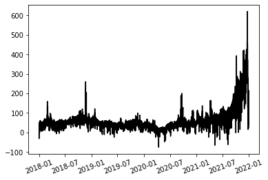

```python
plt.plot(data.date, data.FR_SpotPrice, color='k')
plt.tick_params(axis='x', rotation=20)
plt.show()
```

Here we are cheating a bit, in a pedagogical objective. We should not have a look at what we will try to predict!

**Q7** What do you think of our explanatory variables? What is their temporality with respect to the the temporality of the target (i.e. of what we aim at predicting, the spot prices)? What do you propose? Do you think about a better approach?

Some variables are not always available at the same time. To avoid the forward-looking bias, we propose to shift some variables of 48 hours.

Shift the explanatory variables of 48h. *Tips: use .shift()*

```python
data.FR_Load
```

```
0        56036.0
1        54494.0
2        51574.0
3        49370.0
4        49000.0
          ...
35059    54155.0
35060    51945.0
35061    52907.0
35062    54542.0
35063    54542.0
Name: FR_Load, Length: 35064, dtype: float64
```

```python
data.FR_Load.shift(48)
```

```
0            NaN
1            NaN
2            NaN
3            NaN
4            NaN
          ...
35059    55981.0
35060    53098.0
35061    53174.0
35062    53783.0
35063    51009.0
Name: FR_Load, Length: 35064, dtype: float64
```

```python
data.FR_Load.shift(48)[48:64]
```

```
48    56036.0
49    54494.0
50    51574.0
51    49370.0
52    49000.0
53    49333.0
54    49528.0
55    49360.0
56    50058.0
57    51855.0
58    54412.0
59    57142.0
60    56650.0
61    54628.0
62    53357.0
63    53522.0
Name: FR_Load, dtype: float64
```

```python
for variable in data.columns[2:]:
    data[variable] = data[variable].shift(48)
```

```python
data.iloc[48:64,:]
```

|  | date | FR_SpotPrice | FR_Load | FR_Biomass | FR_Fossil_Gas | FR_Fossil_Hard_coal | FR_Fossil_Oil | FR_Hydro_Pumped_Storage | FR_Hydro_Run-of-river_and_poundage | FR_Hydro_Water_Reservoir | ... | Export_FR_ES | Export_FR_GB | Export_FR_IT_North | Export_FR_DE | ES_SpotPrice | BE_SpotPrice | CH_SpotPrice | IT_SpotPrice | UK_SpotPrice | DE_SpotPrice |
| --- | --- | --- | --- | --- | --- | --- | --- | --- | --- | --- | --- | --- | --- | --- | --- | --- | --- | --- | --- | --- | --- |
| 48 | 2018-01-03 00:00:00 | 5.48 | 56036.0 | 293.0 | 2316.0 | 11.0 | 214.0 | -1343.0 | 5786.0 | 2160.0 | ... | -675.18 | -1409.0 | -516.0 | 0.0 | 4.74 | 4.74 | 31.08 | 44.16 | 47.14 | -29.99 |
| 49 | 2018-01-03 01:00:00 | 5.00 | 54494.0 | 293.0 | 2286.0 | 11.0 | 215.0 | -1394.0 | 5593.0 | 1571.0 | ... | -548.63 | -1410.0 | -258.0 | 0.0 | 3.66 | 3.66 | 29.17 | 42.24 | 54.60 | -56.65 |
| 50 | 2018-01-03 02:00:00 | 0.99 | 51574.0 | 294.0 | 2290.0 | 11.0 | 214.0 | -1344.0 | 5507.0 | 1319.0 | ... | -2727.06 | -1316.0 | -207.0 | 0.0 | 2.30 | 1.26 | 21.96 | 39.29 | 46.63 | -63.14 |
| 51 | 2018-01-03 03:00:00 | -0.25 | 49370.0 | 294.0 | 2291.0 | 10.0 | 215.0 | -1840.0 | 5261.0 | 705.0 | ... | -2787.70 | -1318.0 | -210.0 | 0.0 | 2.30 | -20.10 | 14.96 | 36.00 | 39.90 | -64.62 |
| 52 | 2018-01-03 04:00:00 | 3.87 | 49000.0 | 294.0 | 2271.0 | 10.0 | 217.0 | -2527.0 | 5233.0 | 482.0 | ... | -2802.13 | -1318.0 | 0.0 | 0.0 | 2.06 | -31.82 | -5.92 | 41.99 | 23.41 | -67.00 |
| 53 | 2018-01-03 05:00:00 | 12.25 | 49333.0 | 294.0 | 2275.0 | 11.0 | 217.0 | -2830.0 | 5345.0 | 750.0 | ... | -2779.69 | -1318.0 | 0.0 | 0.0 | 2.06 | -28.66 | -6.10 | 42.25 | 23.61 | -72.54 |
| 54 | 2018-01-03 06:00:00 | 19.42 | 49528.0 | 294.0 | 2393.0 | 11.0 | 216.0 | -2777.0 | 5462.0 | 918.0 | ... | -2565.37 | -1319.0 | 0.0 | 0.0 | 2.06 | -13.71 | -10.02 | 44.97 | 29.96 | -76.01 |
| 55 | 2018-01-03 07:00:00 | 22.57 | 49360.0 | 294.0 | 2414.0 | 10.0 | 215.0 | -2757.0 | 5504.0 | 1372.0 | ... | -2796.37 | -821.0 | -38.0 | 0.0 | 2.30 | -19.33 | -5.71 | 45.00 | 24.09 | -71.45 |
| 56 | 2018-01-03 08:00:00 | 22.37 | 50058.0 | 294.0 | 2412.0 | 11.0 | 214.0 | -2596.0 | 5764.0 | 1253.0 | ... | -2517.68 | -710.0 | -112.0 | 0.0 | 2.30 | -15.78 | -1.88 | 44.94 | 24.14 | -66.88 |
| 57 | 2018-01-03 09:00:00 | 18.65 | 51855.0 | 293.0 | 2408.0 | 11.0 | 214.0 | -2975.0 | 5718.0 | 756.0 | ... | -2739.49 | -1315.0 | 0.0 | 0.0 | 2.30 | -12.05 | -10.48 | 45.04 | 42.00 | -62.00 |
| 58 | 2018-01-03 10:00:00 | 19.35 | 54412.0 | 290.0 | 2404.0 | 11.0 | 213.0 | -3083.0 | 5781.0 | 880.0 | ... | -2069.06 | -1818.0 | 0.0 | 0.0 | 2.30 | -0.42 | -6.79 | 46.67 | 57.00 | -56.08 |
| 59 | 2018-01-03 11:00:00 | 18.93 | 57142.0 | 291.0 | 2400.0 | 11.0 | 213.0 | -2732.0 | 5870.0 | 1479.0 | ... | -625.18 | -1818.0 | 0.0 | 0.0 | 2.30 | 2.30 | 8.57 | 46.99 | 43.40 | -49.96 |
| 60 | 2018-01-03 12:00:00 | 17.26 | 56650.0 | 293.0 | 2399.0 | 11.0 | 215.0 | -2605.0 | 5741.0 | 1798.0 | ... | -591.83 | -1818.0 | 0.0 | 0.0 | 2.30 | 2.30 | 8.53 | 44.16 | 51.86 | -24.29 |
| 61 | 2018-01-03 13:00:00 | 16.76 | 54628.0 | 294.0 | 2394.0 | 11.0 | 215.0 | -1493.0 | 5775.0 | 2485.0 | ... | 0.00 | -1818.0 | -165.0 | 0.0 | 5.00 | 13.76 | 8.52 | 45.26 | 55.00 | -5.59 |
| 62 | 2018-01-03 14:00:00 | 18.09 | 53357.0 | 294.0 | 2398.0 | 12.0 | 216.0 | -1149.0 | 5780.0 | 2240.0 | ... | 0.00 | -1812.0 | -664.0 | -781.0 | 5.00 | 15.43 | 8.60 | 47.84 | 55.00 | 0.23 |
| 63 | 2018-01-03 15:00:00 | 19.51 | 53522.0 | 294.0 | 2399.0 | 9.0 | 216.0 | -729.0 | 5750.0 | 2030.0 | ... | 0.00 | -2015.0 | -914.0 | -1571.0 | 5.00 | 25.46 | 16.98 | 50.10 | 57.88 | 11.02 |

16 rows × 32 columns

**Q8** What do you think will be the important and useful information from the *date* variable? Extract them!

*Tips: use date.dt*

```python
data['Year'] = data.date.dt.year
data['Month'] = data.date.dt.month
data['Weekday'] = data.date.dt.weekday
data['Hour'] = data.date.dt.hour
```

## Split the data before learning anything

Back to table of contents.

We aim at learning a general relationship between input features and a label/target.  
We wish to use this learnt relationship to predict on future unseen values.  
We will start by re-creating this setting: we will keeping some final values unused and try to predict them as if we were back on that time! But this time, we will be able to quantify our errors.

In addition to the pedagogical objective, it can also help us regarding overfitting.  
To avoid overfitting, or at least quantify it, we need to test our forecasting models on unobserved data during the training phase.  
A classical approach is to split a training and a testing set. The training set allows the calibration of the parameters of a model, while the testing set evaluates the generalization ability.

**Q9** Create an extract of *data*, _data_train_, where the data stops at 2019-06-30 23h. We keep the last semester of 2019 to predict.

_Tips: Define limit_train with datetime.strptime, the date where the training set stops, and use this time stamp to extract data_train._

```python
limit_train = datetime.strptime('2019-06-30 23:00:00', "%Y-%m-%d %H:%M:%S")
```

```python
data_train = data.loc[data.date <= limit_train,:]
data_train = data_train.drop(np.arange(48), axis=0) ## Initials NA because of lagged variables
```

```python
data_train.tail(10)
```

|  | date | FR_SpotPrice | FR_Load | FR_Biomass | FR_Fossil_Gas | FR_Fossil_Hard_coal | FR_Fossil_Oil | FR_Hydro_Pumped_Storage | FR_Hydro_Run-of-river_and_poundage | FR_Hydro_Water_Reservoir | ... | ES_SpotPrice | BE_SpotPrice | CH_SpotPrice | IT_SpotPrice | UK_SpotPrice | DE_SpotPrice | Year | Month | Weekday | Hour |
| --- | --- | --- | --- | --- | --- | --- | --- | --- | --- | --- | --- | --- | --- | --- | --- | --- | --- | --- | --- | --- | --- |
| 13094 | 2019-06-30 14:00:00 | 4.36 | 54198.0 | 294.0 | 4259.0 | 18.0 | 144.0 | 332.0 | 5716.0 | 1298.0 | ... | 51.36 | 34.40 | 34.17 | 59.42 | 31.62 | 34.40 | 2019 | 6 | 6 | 14 |
| 13095 | 2019-06-30 15:00:00 | 20.05 | 53679.0 | 294.0 | 4290.0 | 19.0 | 143.0 | 784.0 | 5976.0 | 1418.0 | ... | 51.20 | 39.04 | 37.95 | 58.50 | 35.79 | 39.04 | 2019 | 6 | 6 | 15 |
| 13096 | 2019-06-30 16:00:00 | 28.83 | 53627.0 | 293.0 | 4447.0 | 19.0 | 143.0 | 1484.0 | 6246.0 | 1876.0 | ... | 51.01 | 47.42 | 39.16 | 56.00 | 43.59 | 54.13 | 2019 | 6 | 6 | 16 |
| 13097 | 2019-06-30 17:00:00 | 36.63 | 52660.0 | 294.0 | 4461.0 | 19.0 | 144.0 | 1586.0 | 6314.0 | 2109.0 | ... | 51.20 | 51.12 | 38.99 | 59.01 | 47.00 | 66.53 | 2019 | 6 | 6 | 17 |
| 13098 | 2019-06-30 18:00:00 | 37.94 | 50455.0 | 294.0 | 4476.0 | 19.0 | 143.0 | 1811.0 | 6350.0 | 2247.0 | ... | 51.45 | 50.11 | 37.75 | 59.00 | 48.12 | 66.06 | 2019 | 6 | 6 | 18 |
| 13099 | 2019-06-30 19:00:00 | 37.07 | 48686.0 | 293.0 | 4444.0 | 18.0 | 144.0 | 1265.0 | 6466.0 | 2004.0 | ... | 51.45 | 46.83 | 36.73 | 53.42 | 44.19 | 54.73 | 2019 | 6 | 6 | 19 |
| 13100 | 2019-06-30 20:00:00 | 43.19 | 50775.0 | 294.0 | 4577.0 | 18.0 | 145.0 | 1429.0 | 6465.0 | 2040.0 | ... | 51.20 | 48.54 | 39.85 | 48.54 | 44.49 | 48.54 | 2019 | 6 | 6 | 20 |
| 13101 | 2019-06-30 21:00:00 | 36.72 | 51235.0 | 293.0 | 4563.0 | 18.0 | 145.0 | 2025.0 | 6281.0 | 2068.0 | ... | 50.66 | 39.05 | 37.69 | 44.46 | 35.79 | 39.05 | 2019 | 6 | 6 | 21 |
| 13102 | 2019-06-30 22:00:00 | 28.98 | 46483.0 | 294.0 | 3894.0 | 18.0 | 145.0 | 1048.0 | 5946.0 | 1858.0 | ... | 51.45 | 35.24 | 34.12 | 53.92 | 35.64 | 35.24 | 2019 | 6 | 6 | 22 |
| 13103 | 2019-06-30 23:00:00 | 26.23 | 43038.0 | 295.0 | 2498.0 | 18.0 | 146.0 | 121.0 | 5567.0 | 1082.0 | ... | 49.50 | 30.58 | 31.02 | 51.00 | 31.60 | 31.63 | 2019 | 6 | 6 | 23 |

10 rows × 36 columns

A commun flaw in data science is the missing values.  
Sometimes, using incomplete data could lead to ineffective analysis or erratic training of models.  
Data imputation is a research field at its own, with various methods (see [1]).  
An intuitive approach but non appropriate is to drop observations containing missing values, in order to keep a complete dataset.  
However, by definition every incomplete information is lost. Furthermore, if the missing values depend on your features or on your response, you could loose an entire relationship.  
There are many other ways to handle incomplete dataset: imputing by the mean, by a regression on the other variables, a stochastic regression, k-nearest neighbors and so on.  
In addition, you can sometimes add the treatment of your missing values in your procedure, without imputing beforehand! As said, it is a very active field of research!

Here, we will impute our data, and regress afterwards (not combining both tasks). This is motivated by the work of Le Morvan et al. (2021) [2].  
We propose the fill missing values with mean, as it is simple and the practical session is not dedicated to study the missing values.

[1] https://rmisstastic.netlify.app/  
[2] [Le Morvan et al. (2021)](https://proceedings.neurips.cc/paper/2021/file/5fe8fdc79ce292c39c5f209d734b7206-Paper.pdf)

We can now impute our data set, without using the unseen values.

**Q10** Replace NaN values by the associated variable's means of _data_train_.

The test set (not created yet, that will contain the last 6 months of 2019) shall not contain missing values either!

**Q11** Replace also NaN values of the overall *data* with the same means of _data_train_.

```python
means = data_train.mean(axis=0)
```

```python
means
```

```
FR_SpotPrice                             47.265995
FR_Load                               54675.884695
FR_Biomass                              381.302169
FR_Fossil_Gas                          3703.504177
FR_Fossil_Hard_coal                     498.856464
FR_Fossil_Oil                           208.671776
FR_Hydro_Pumped_Storage                 -88.776228
FR_Hydro_Run-of-river_and_poundage     4911.240938
FR_Hydro_Water_Reservoir               1868.371676
FR_Nuclear                            45420.688788
FR_Solar                               1189.569349
FR_Waste                                221.094107
FR_Wind_Onshore                        3257.124147
Import_FR_BE                            203.428738
Import_FR_CH                            198.869159
Import_FR_ES                            283.929694
Import_FR_GB                             37.166167
Import_FR_IT_North                        7.367494
Import_FR_DE                            250.837277
Export_FR_BE                          -1074.313296
Export_FR_CH                           -801.215761
Export_FR_ES                          -1730.105836
Export_FR_GB                          -1508.520320
Export_FR_IT_North                    -1590.337929
Export_FR_DE                          -1295.293136
ES_SpotPrice                             55.502737
BE_SpotPrice                             50.808577
CH_SpotPrice                             49.121912
IT_SpotPrice                             58.669899
UK_SpotPrice                             53.910352
DE_SpotPrice                             42.502702
Year                                   2018.332721
Month                                     5.542279
Weekday                                   3.009191
Hour                                     11.500000
dtype: float64
```

```python
mask_train_na = data_train.isnull().any(axis=1)
data_train[mask_train_na]
```

|  | date | FR_SpotPrice | FR_Load | FR_Biomass | FR_Fossil_Gas | FR_Fossil_Hard_coal | FR_Fossil_Oil | FR_Hydro_Pumped_Storage | FR_Hydro_Run-of-river_and_poundage | FR_Hydro_Water_Reservoir | ... | ES_SpotPrice | BE_SpotPrice | CH_SpotPrice | IT_SpotPrice | UK_SpotPrice | DE_SpotPrice | Year | Month | Weekday | Hour |
| --- | --- | --- | --- | --- | --- | --- | --- | --- | --- | --- | --- | --- | --- | --- | --- | --- | --- | --- | --- | --- | --- |
| 627 | 2018-01-27 03:00:00 | 32.53 | 51671.0 | 284.0 | 2685.0 | 9.0 | 214.0 | -2523.0 | 5688.0 | 2094.0 | ... | 45.39 | 11.65 | 40.21 | 43.01 | 40.55 | 4.74 | 2018 | 1 | 5 | 3 |
| 2040 | 2018-03-27 00:00:00 | 38.00 | 57232.0 | 486.0 | 3509.0 | 1495.0 | 199.0 | -292.0 | 5282.0 | 2559.0 | ... | 45.00 | 46.00 | 36.12 | 46.00 | 59.99 | 38.01 | 2018 | 3 | 1 | 0 |
| 2071 | 2018-03-28 07:00:00 | 56.80 | NaN | NaN | NaN | NaN | NaN | NaN | NaN | NaN | ... | 60.13 | 76.61 | 67.95 | 76.61 | 69.02 | 76.61 | 2018 | 3 | 2 | 7 |
| 2816 | 2018-04-28 08:00:00 | 21.01 | NaN | 582.0 | 830.0 | 3.0 | 175.0 | 1355.0 | 7170.0 | 2093.0 | ... | 49.77 | 37.65 | 37.03 | 50.52 | 50.12 | 33.97 | 2018 | 4 | 5 | 8 |
| 2817 | 2018-04-28 09:00:00 | 23.27 | 53618.0 | 587.0 | 769.0 | 3.0 | 175.0 | 1080.0 | 7394.0 | 2114.0 | ... | 50.00 | 38.23 | 36.20 | 49.62 | 44.01 | 31.15 | 2018 | 4 | 5 | 9 |
| ... | ... | ... | ... | ... | ... | ... | ... | ... | ... | ... | ... | ... | ... | ... | ... | ... | ... | ... | ... | ... | ... |
| 12617 | 2019-06-10 17:00:00 | 40.00 | 41664.0 | 404.0 | 536.0 | 13.0 | 143.0 | -273.0 | 5927.0 | 1455.0 | ... | 42.48 | -50.10 | 25.49 | 43.69 | NaN | 10.54 | 2019 | 6 | 0 | 17 |
| 12618 | 2019-06-10 18:00:00 | 39.74 | 40827.0 | 404.0 | 537.0 | 13.0 | 142.0 | -367.0 | 5897.0 | 2096.0 | ... | 44.11 | -4.60 | 28.89 | 48.73 | NaN | 23.54 | 2019 | 6 | 0 | 18 |
| 12619 | 2019-06-10 19:00:00 | 39.70 | 40769.0 | 404.0 | 536.0 | 13.0 | 143.0 | 259.0 | 5894.0 | 2089.0 | ... | 49.01 | 15.00 | 29.20 | 49.09 | NaN | 25.47 | 2019 | 6 | 0 | 19 |
| 12620 | 2019-06-10 20:00:00 | 40.00 | 43694.0 | 405.0 | 548.0 | 12.0 | 142.0 | 1425.0 | 5997.0 | 2230.0 | ... | 49.02 | 30.70 | 30.55 | 40.23 | NaN | 27.31 | 2019 | 6 | 0 | 20 |
| 12621 | 2019-06-10 21:00:00 | 35.06 | 45357.0 | 405.0 | 558.0 | 12.0 | 142.0 | 1987.0 | 6065.0 | 2652.0 | ... | 44.83 | 32.50 | 28.71 | 36.10 | NaN | 20.84 | 2019 | 6 | 0 | 21 |

79 rows × 36 columns

```python
data_train = data_train.fillna(means)
```

```python
data_train[mask_train_na]
```

|  | date | FR_SpotPrice | FR_Load | FR_Biomass | FR_Fossil_Gas | FR_Fossil_Hard_coal | FR_Fossil_Oil | FR_Hydro_Pumped_Storage | FR_Hydro_Run-of-river_and_poundage | FR_Hydro_Water_Reservoir | ... | ES_SpotPrice | BE_SpotPrice | CH_SpotPrice | IT_SpotPrice | UK_SpotPrice | DE_SpotPrice | Year | Month | Weekday | Hour |
| --- | --- | --- | --- | --- | --- | --- | --- | --- | --- | --- | --- | --- | --- | --- | --- | --- | --- | --- | --- | --- | --- |
| 627 | 2018-01-27 03:00:00 | 32.53 | 51671.000000 | 284.000000 | 2685.000000 | 9.000000 | 214.000000 | -2523.000000 | 5688.000000 | 2094.000000 | ... | 45.39 | 11.65 | 40.21 | 43.01 | 40.550000 | 4.74 | 2018 | 1 | 5 | 3 |
| 2040 | 2018-03-27 00:00:00 | 38.00 | 57232.000000 | 486.000000 | 3509.000000 | 1495.000000 | 199.000000 | -292.000000 | 5282.000000 | 2559.000000 | ... | 45.00 | 46.00 | 36.12 | 46.00 | 59.990000 | 38.01 | 2018 | 3 | 1 | 0 |
| 2071 | 2018-03-28 07:00:00 | 56.80 | 54675.884695 | 381.302169 | 3703.504177 | 498.856464 | 208.671776 | -88.776228 | 4911.240938 | 1868.371676 | ... | 60.13 | 76.61 | 67.95 | 76.61 | 69.020000 | 76.61 | 2018 | 3 | 2 | 7 |
| 2816 | 2018-04-28 08:00:00 | 21.01 | 54675.884695 | 582.000000 | 830.000000 | 3.000000 | 175.000000 | 1355.000000 | 7170.000000 | 2093.000000 | ... | 49.77 | 37.65 | 37.03 | 50.52 | 50.120000 | 33.97 | 2018 | 4 | 5 | 8 |
| 2817 | 2018-04-28 09:00:00 | 23.27 | 53618.000000 | 587.000000 | 769.000000 | 3.000000 | 175.000000 | 1080.000000 | 7394.000000 | 2114.000000 | ... | 50.00 | 38.23 | 36.20 | 49.62 | 44.010000 | 31.15 | 2018 | 4 | 5 | 9 |
| ... | ... | ... | ... | ... | ... | ... | ... | ... | ... | ... | ... | ... | ... | ... | ... | ... | ... | ... | ... | ... | ... |
| 12617 | 2019-06-10 17:00:00 | 40.00 | 41664.000000 | 404.000000 | 536.000000 | 13.000000 | 143.000000 | -273.000000 | 5927.000000 | 1455.000000 | ... | 42.48 | -50.10 | 25.49 | 43.69 | 53.910352 | 10.54 | 2019 | 6 | 0 | 17 |
| 12618 | 2019-06-10 18:00:00 | 39.74 | 40827.000000 | 404.000000 | 537.000000 | 13.000000 | 142.000000 | -367.000000 | 5897.000000 | 2096.000000 | ... | 44.11 | -4.60 | 28.89 | 48.73 | 53.910352 | 23.54 | 2019 | 6 | 0 | 18 |
| 12619 | 2019-06-10 19:00:00 | 39.70 | 40769.000000 | 404.000000 | 536.000000 | 13.000000 | 143.000000 | 259.000000 | 5894.000000 | 2089.000000 | ... | 49.01 | 15.00 | 29.20 | 49.09 | 53.910352 | 25.47 | 2019 | 6 | 0 | 19 |
| 12620 | 2019-06-10 20:00:00 | 40.00 | 43694.000000 | 405.000000 | 548.000000 | 12.000000 | 142.000000 | 1425.000000 | 5997.000000 | 2230.000000 | ... | 49.02 | 30.70 | 30.55 | 40.23 | 53.910352 | 27.31 | 2019 | 6 | 0 | 20 |
| 12621 | 2019-06-10 21:00:00 | 35.06 | 45357.000000 | 405.000000 | 558.000000 | 12.000000 | 142.000000 | 1987.000000 | 6065.000000 | 2652.000000 | ... | 44.83 | 32.50 | 28.71 | 36.10 | 53.910352 | 20.84 | 2019 | 6 | 0 | 21 |

79 rows × 36 columns

```python
data = data.fillna(means)
```

# Exploratory Data Analysis

Back to table of contents.

Several basic tools are useful to better understand the data.  
Here we propose to explore some of them.  
We focus of analysing the training set, to avoid adding some prior of events which did not occur yet.  
A major task in data analysis is the study of the relationship between a given feature and the target, since it is what we are trying to learn. We will try to get some insights on these relationships.

**Q12** Plot the histogram of the french spot prices. It illustrates the probability distribution of the data.

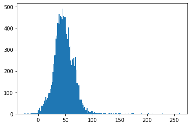

```python
plt.hist(data_train.FR_SpotPrice, bins=200)
plt.show()
```

The previous histogram only displays the overall distribution. We added some calendar information, we can try to assess the relations between the price and these calendar information!

**Q13** Show the boxplot of the french spot prices by *Weekday*, *Month* and *Hour*.

Boxplots illustrate average and spread of a given variable.

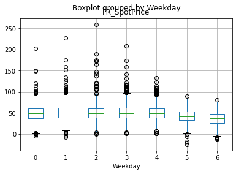

```python
data_train.boxplot(column='FR_SpotPrice',by='Weekday')
plt.show()
```

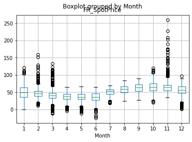

```python
data_train.boxplot(column='FR_SpotPrice',by='Month')
plt.show()
```

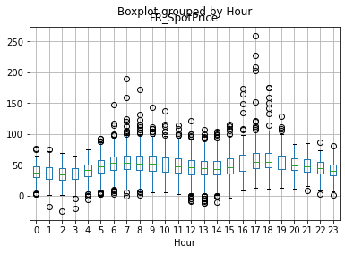

```python
data_train.boxplot(column='FR_SpotPrice',by='Hour')
plt.show()
```

We observe patterns, on the mean but also on the variance, depending on these calendar variables:

- lower and less variable prices on the week-end (lower industrial consumption)
- higher prices in Fall and Winter (higher consumption)
- prices more variable in Winter (lower renewable production)
- lower prices during the nighs, and peaks around 9 a.m. and 6 p.m. with huge variance at 6 p.m.

**Q14** What is the limitation of boxplots?

Violin plots are similar to box plots but shows the estimated probability density as well.  
One can see the references to go further on the violin plots:  
https://en.wikipedia.org/wiki/Violin_plot  
https://seaborn.pydata.org/generated/seaborn.violinplot.html  
https://chartio.com/learn/charts/violin-plot-complete-guide/  
https://mode.com/blog/violin-plot-examples/

**Q15** Show the violin plot of the french spot prices by *Weekday*, *Month* and *Hour*.

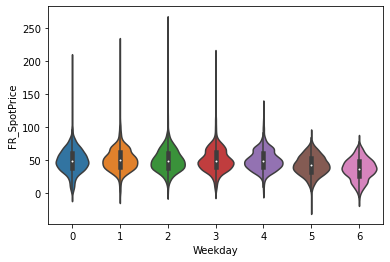

```python
sns.violinplot(x='Weekday',y='FR_SpotPrice', data=data_train)
plt.show()
```

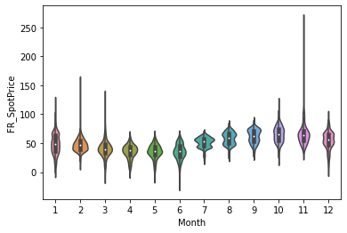

```python
sns.violinplot(x='Month',y='FR_SpotPrice', data=data_train)
plt.show()
```

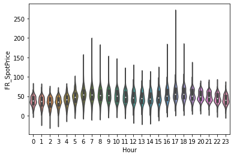

```python
sns.violinplot(x='Hour',y='FR_SpotPrice', data=data_train)
plt.show()
```

Sometimes, plotting this relationship between two series of data in a graph allows to better understand it, or exhibits linear or polynomial relations.

**Q16** Plot the french spot price according to each variables, with its label in absciss.

**Q17** When/what can you conclude?

*Tips: use scatter plot*

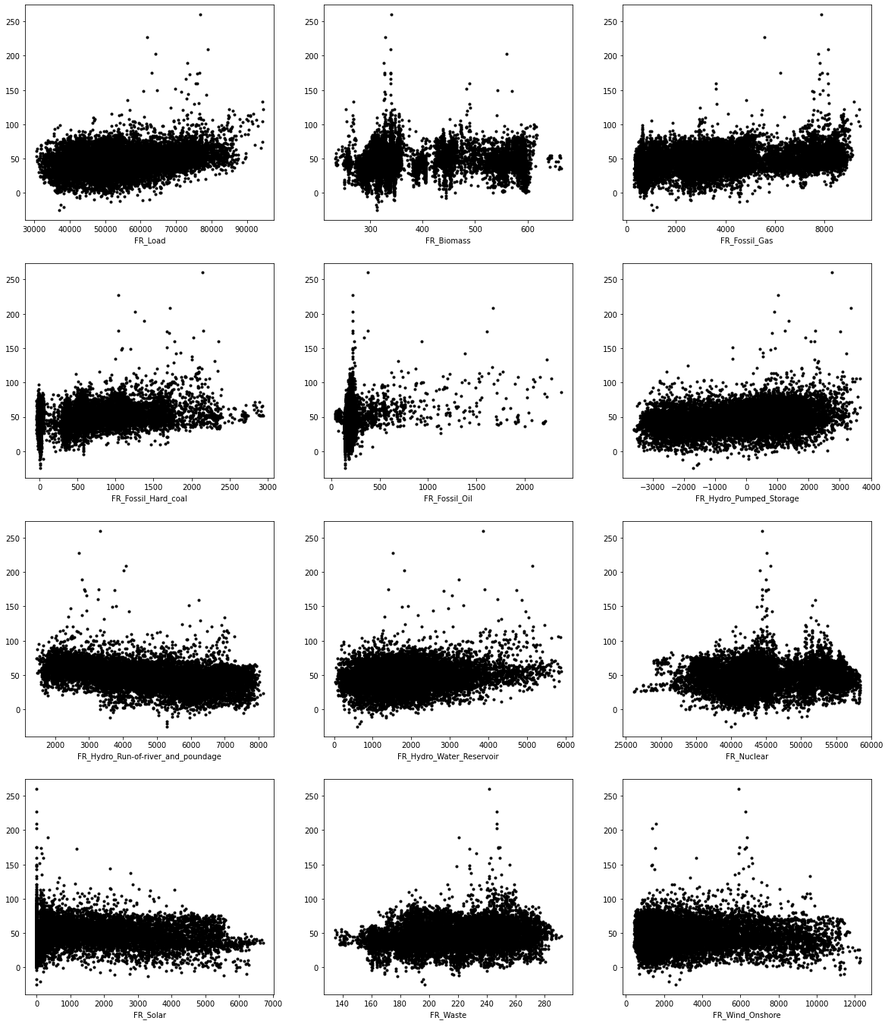

```python
ncol = 3
nrow = 4
fig, axes = plt.subplots(nrow,ncol, figsize=(20,24))
for k,variable in enumerate(data_train.columns[2:14]):
    axes[k//ncol, k%ncol].scatter(data_train[variable], data_train.FR_SpotPrice, marker='.', color='black')
    #axes[k//ncol, k%ncol].plot([0,1],[0,1], transform=axes[k//ncol, k%ncol].transAxes)
    axes[k//ncol, k%ncol].set_xlabel(variable)
```

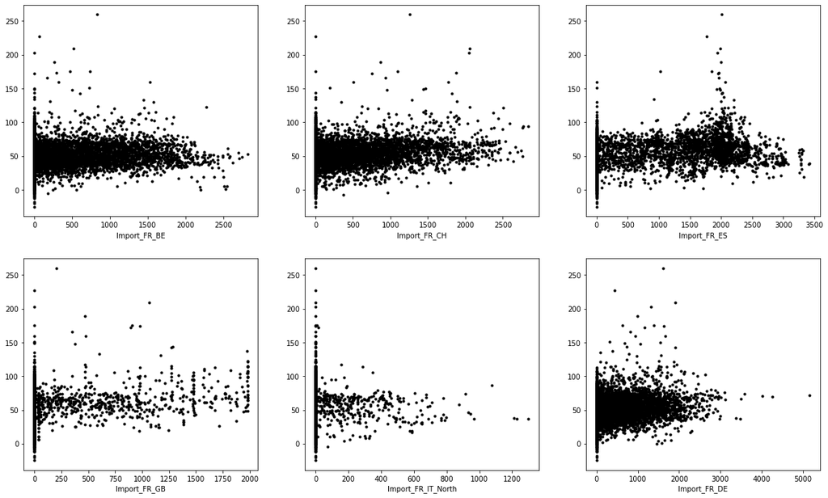

```python
ncol = 3
nrow = 2
fig, axes = plt.subplots(nrow,ncol, figsize=(20,12))
for k,variable in enumerate(data_train.columns[14:20]):
    axes[k//ncol, k%ncol].scatter(data_train[variable], data_train.FR_SpotPrice, marker='.', color='black')
    #axes[k//ncol, k%ncol].plot([0,1],[0,1], transform=axes[k//ncol, k%ncol].transAxes)
    axes[k//ncol, k%ncol].set_xlabel(variable)
```

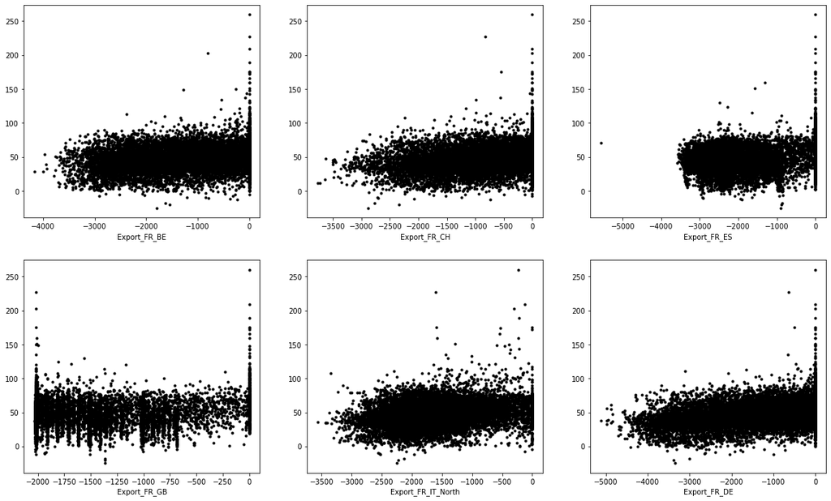

```python
ncol = 3
nrow = 2
fig, axes = plt.subplots(nrow,ncol, figsize=(20,12))
for k,variable in enumerate(data_train.columns[20:26]):
    axes[k//ncol, k%ncol].scatter(data_train[variable], data_train.FR_SpotPrice, marker='.', color='black')
    #axes[k//ncol, k%ncol].plot([0,1],[0,1], transform=axes[k//ncol, k%ncol].transAxes)
    axes[k//ncol, k%ncol].set_xlabel(variable)
```

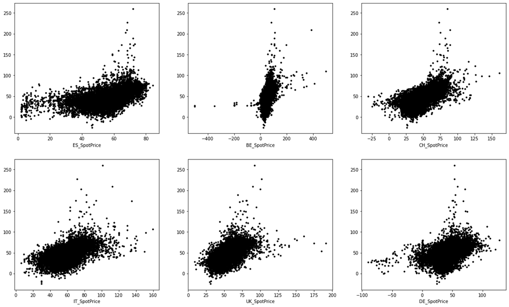

```python
ncol = 3
nrow = 2
fig, axes = plt.subplots(nrow,ncol, figsize=(20,12))
for k,variable in enumerate(data_train.columns[26:32]):
    axes[k//ncol, k%ncol].scatter(data_train[variable], data_train.FR_SpotPrice, marker='.', color='black')
    #axes[k//ncol, k%ncol].plot([0,1],[0,1], transform=axes[k//ncol, k%ncol].transAxes)
    axes[k//ncol, k%ncol].set_xlabel(variable)
```

**Q18** Plot the correlation matrice between all variables. What can you say?

*Tips: use corr function and heatmap*

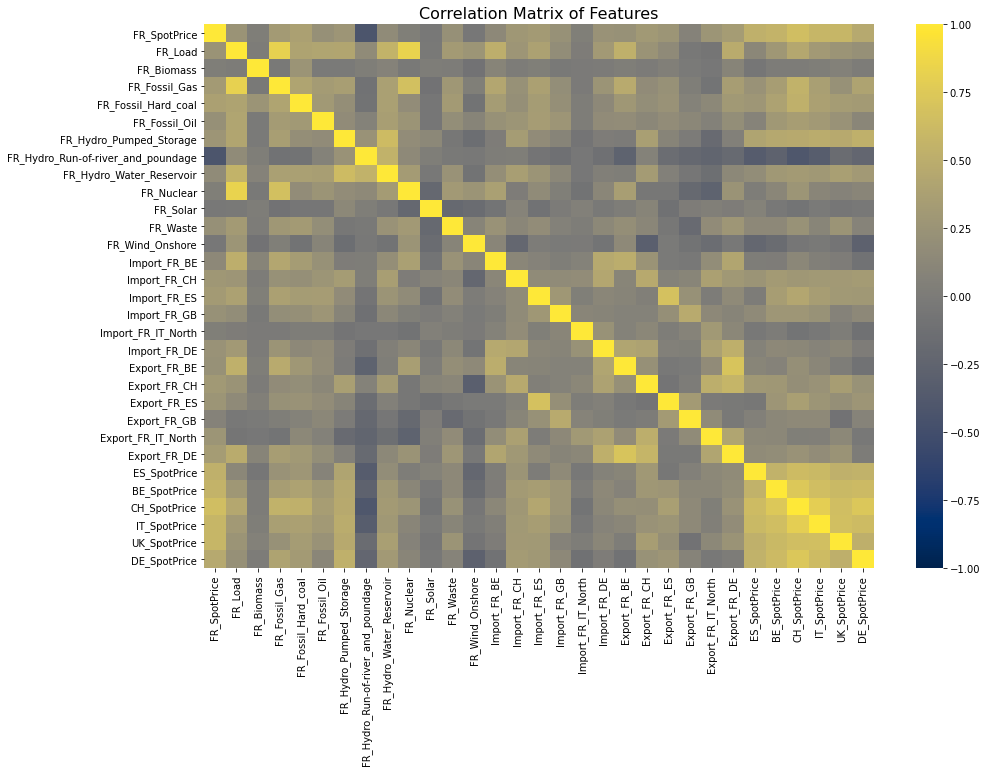

```python
fig, ax = plt.subplots(figsize=(15,10))

corrmat = data_train.iloc[:,1:32].corr()

sns.heatmap(corrmat, vmin=-1, vmax=1, cmap='cividis')

plt.title('Correlation Matrix of Features', fontsize=16)
plt.show()
```

Warning: correlation is not causality. This is just a hint, nothing more!

# Forecasting last semester of 2019

Back to table of contents.

Having analysed our data, we can proceed to the forecasting task. First, we need to create our testing set.

**Q19** Define _data_test_, stopping at 2019-12-31 23h.

```python
limit_test = datetime.strptime('2019-12-31 23:00:00', "%Y-%m-%d %H:%M:%S")
data_test = data.loc[(data.date > limit_train) & (data.date <= limit_test),:]
```

```python
data_test.head(10)
```

|  | date | FR_SpotPrice | FR_Load | FR_Biomass | FR_Fossil_Gas | FR_Fossil_Hard_coal | FR_Fossil_Oil | FR_Hydro_Pumped_Storage | FR_Hydro_Run-of-river_and_poundage | FR_Hydro_Water_Reservoir | ... | ES_SpotPrice | BE_SpotPrice | CH_SpotPrice | IT_SpotPrice | UK_SpotPrice | DE_SpotPrice | Year | Month | Weekday | Hour |
| --- | --- | --- | --- | --- | --- | --- | --- | --- | --- | --- | --- | --- | --- | --- | --- | --- | --- | --- | --- | --- | --- |
| 13104 | 2019-07-01 00:00:00 | 24.26 | 40927.0 | 295.0 | 2100.0 | 18.0 | 144.0 | -342.0 | 5316.0 | 849.0 | ... | 49.42 | 24.61 | 30.02 | 45.43 | 28.02 | 29.88 | 2019 | 7 | 0 | 0 |
| 13105 | 2019-07-01 01:00:00 | 21.42 | 38586.0 | 295.0 | 1632.0 | 18.0 | 144.0 | -1352.0 | 5136.0 | 632.0 | ... | 49.50 | 27.48 | 29.18 | 43.99 | 27.00 | 29.13 | 2019 | 7 | 0 | 1 |
| 13106 | 2019-07-01 02:00:00 | 19.61 | 37433.0 | 295.0 | 1663.0 | 18.0 | 145.0 | -1581.0 | 5052.0 | 606.0 | ... | 50.00 | 25.10 | 28.60 | 43.33 | 27.39 | 29.52 | 2019 | 7 | 0 | 2 |
| 13107 | 2019-07-01 03:00:00 | 16.27 | 37149.0 | 294.0 | 1717.0 | 18.0 | 145.0 | -1534.0 | 5055.0 | 584.0 | ... | 50.10 | 25.10 | 28.12 | 42.62 | 27.73 | 28.76 | 2019 | 7 | 0 | 3 |
| 13108 | 2019-07-01 04:00:00 | 23.80 | 37516.0 | 294.0 | 1557.0 | 19.0 | 146.0 | -1439.0 | 5106.0 | 621.0 | ... | 45.91 | 24.80 | 29.12 | 45.00 | 27.93 | 30.06 | 2019 | 7 | 0 | 4 |
| 13109 | 2019-07-01 05:00:00 | 37.30 | 39524.0 | 294.0 | 1697.0 | 19.0 | 146.0 | -1055.0 | 5303.0 | 671.0 | ... | 45.91 | 28.45 | 30.35 | 48.47 | 34.92 | 31.48 | 2019 | 7 | 0 | 5 |
| 13110 | 2019-07-01 06:00:00 | 39.66 | 42759.0 | 295.0 | 2257.0 | 19.0 | 145.0 | 111.0 | 5586.0 | 1146.0 | ... | 48.50 | 27.74 | 31.67 | 53.92 | 35.00 | 30.15 | 2019 | 7 | 0 | 6 |
| 13111 | 2019-07-01 07:00:00 | 41.13 | 45976.0 | 295.0 | 2237.0 | 19.0 | 145.0 | 371.0 | 5791.0 | 1350.0 | ... | 50.40 | 30.15 | 30.67 | 53.92 | 38.92 | 30.15 | 2019 | 7 | 0 | 7 |
| 13112 | 2019-07-01 08:00:00 | 37.57 | 48028.0 | 295.0 | 2098.0 | 19.0 | 145.0 | 332.0 | 5749.0 | 1136.0 | ... | 50.10 | 28.07 | 29.83 | 51.74 | 46.62 | 28.07 | 2019 | 7 | 0 | 8 |
| 13113 | 2019-07-01 09:00:00 | 32.85 | 49612.0 | 295.0 | 1892.0 | 18.0 | 145.0 | -74.0 | 5666.0 | 1015.0 | ... | 50.11 | 28.01 | 29.12 | 44.00 | 42.00 | 28.01 | 2019 | 7 | 0 | 9 |

10 rows × 36 columns

```python
data_test.tail(10)
```

|  | date | FR_SpotPrice | FR_Load | FR_Biomass | FR_Fossil_Gas | FR_Fossil_Hard_coal | FR_Fossil_Oil | FR_Hydro_Pumped_Storage | FR_Hydro_Run-of-river_and_poundage | FR_Hydro_Water_Reservoir | ... | ES_SpotPrice | BE_SpotPrice | CH_SpotPrice | IT_SpotPrice | UK_SpotPrice | DE_SpotPrice | Year | Month | Weekday | Hour |
| --- | --- | --- | --- | --- | --- | --- | --- | --- | --- | --- | --- | --- | --- | --- | --- | --- | --- | --- | --- | --- | --- |
| 17510 | 2019-12-31 14:00:00 | 39.58 | 56045.0 | 344.0 | 2512.0 | 37.0 | 178.0 | 357.0 | 6344.0 | 2586.0 | ... | 31.39 | 32.03 | 29.54 | 32.86 | 36.00 | 32.86 | 2019 | 12 | 1 | 14 |
| 17511 | 2019-12-31 15:00:00 | 42.28 | 55801.0 | 345.0 | 2855.0 | 37.0 | 178.0 | 392.0 | 6501.0 | 2545.0 | ... | 33.97 | 33.97 | 32.23 | 35.64 | 34.00 | 33.97 | 2019 | 12 | 1 | 15 |
| 17512 | 2019-12-31 16:00:00 | 46.06 | 60039.0 | 342.0 | 3290.0 | 37.0 | 178.0 | 1285.0 | 6725.0 | 3120.0 | ... | 41.00 | 41.92 | 38.02 | 41.00 | 51.06 | 39.53 | 2019 | 12 | 1 | 16 |
| 17513 | 2019-12-31 17:00:00 | 47.73 | 64336.0 | 344.0 | 3512.0 | 38.0 | 177.0 | 2402.0 | 6926.0 | 4130.0 | ... | 43.50 | 44.97 | 39.97 | 43.50 | 55.61 | 41.16 | 2019 | 12 | 1 | 17 |
| 17514 | 2019-12-31 18:00:00 | 46.00 | 65937.0 | 343.0 | 3518.0 | 38.0 | 178.0 | 2447.0 | 6984.0 | 4427.0 | ... | 43.50 | 45.94 | 39.97 | 43.50 | 46.80 | 39.60 | 2019 | 12 | 1 | 18 |
| 17515 | 2019-12-31 19:00:00 | 42.20 | 64448.0 | 342.0 | 3481.0 | 37.0 | 177.0 | 1768.0 | 6912.0 | 3854.0 | ... | 40.00 | 41.02 | 38.06 | 40.00 | 39.94 | 38.14 | 2019 | 12 | 1 | 19 |
| 17516 | 2019-12-31 20:00:00 | 39.74 | 62679.0 | 342.0 | 3413.0 | 37.0 | 177.0 | 1303.0 | 6866.0 | 3217.0 | ... | 41.15 | 36.60 | 34.79 | 35.03 | 35.84 | 32.00 | 2019 | 12 | 1 | 20 |
| 17517 | 2019-12-31 21:00:00 | 38.88 | 63851.0 | 342.0 | 3387.0 | 37.0 | 177.0 | 1354.0 | 6555.0 | 2985.0 | ... | 39.06 | 36.82 | 34.09 | 34.30 | 32.44 | 30.11 | 2019 | 12 | 1 | 21 |
| 17518 | 2019-12-31 22:00:00 | 37.37 | 65287.0 | 342.0 | 3516.0 | 37.0 | 176.0 | 1060.0 | 6530.0 | 2948.0 | ... | 34.90 | 30.40 | 31.16 | 28.94 | 25.32 | 25.52 | 2019 | 12 | 1 | 22 |
| 17519 | 2019-12-31 23:00:00 | 41.88 | 63016.0 | 342.0 | 2964.0 | 44.0 | 176.0 | -324.0 | 6310.0 | 2578.0 | ... | 33.10 | 30.00 | 27.57 | 26.06 | 24.97 | 11.07 | 2019 | 12 | 1 | 23 |

10 rows × 36 columns

## Tools

Back to table of contents.

#### Split X and Y

Models will need to distinguish between variables/features (the X) and the response (the Y).

**Q20** Define X_train and Y_train.

```python
X_train = data_train.iloc[:,2:data_train.shape[1]]
Y_train = data_train.loc[:,'FR_SpotPrice']
```

#### Metrics

We will evaluate the different forecasting models with three metrics. Many more would be available!

R2 : $$R2 = 1- \frac{\sum^T_{t=1} (y_t - \hat{y_t})^2}{\sum^T_{t=1} (y_t - \bar{y})^2}$$ Mean Absolute Error : $$MAE(y_t,\hat{y_t}) =\frac{1}{T}\sum^T_{t=1} |y_t - \hat{y_t}|$$ Mean Squared Error : $$MSE(y_t,\hat{y_t}) = \frac{1}{T}\sum^T_{t=1} (y_t - \hat{y_t})^2$$ where vectors $y_t$ and $\hat{y_t}$ are respectively the real values to be predicted and the predictions, $\bar{y}$ is the average of $y_t$.

- The MSE reports the squared error of the predictions, and is very sensitive to the outliers to improve the estimation accuracy. The lower, the better. To keep the same unit, we prefer to report the Root Mean Squared Error: $\sqrt{MSE}$.
- The MAE reports the absolute error of the predictions. As the MSE, the lower the better, but it is less sensitive to outliers.
- The R2 represents the proportion of the variance for a dependent variable that is explained by a collection of variables. It is a correlation coefficient (so the same precautions that we take regarding correlations has to be taken with respect to R2). In the best case, the modeled values exactly match the observed values, which results in R2 = 1. A baseline model, which always predicts $\bar{y}$ , will have R2 = 0. Models that have worse predictions than this baseline will have a negative R2. See more in the [wiki page](https://en.wikipedia.org/wiki/Coefficient_of_determination).

**Q21** Define a function _regression_results_ taking true and predicted values, and printing the R2, MAE and RMSE scores.

```python
import sklearn.metrics as metrics
```

```python
def regression_results(y_true, y_pred):
    mae = metrics.mean_absolute_error(y_true, y_pred)
    mse = metrics.mean_squared_error(y_true, y_pred)
    r2 = metrics.r2_score(y_true, y_pred)
    print('r2: ', round(r2,4))
    print('MAE: ', round(mae,4))
    print('RMSE: ', round(np.sqrt(mse),4))
```

#### Models

**Linear regression**
Linear regression models the label (or target) $y\in\mathbb{R}$ as a linear combination of the $d$-dimensional input $x \in \mathbb{R}^d$: $$\hat{y}(w,x)=w_0+w_1x_1+\dots+w_dx_d$$

The parameter $w=(w_0,\dots,w_d)\in \mathbb{R}^{d+1}$ is fitted by minimizing the loss function $\ell(w)$ on the data, according to $w$: $$\ell(w) = ||y - X w||^2_2 = \sum_{i=1}^N (y_i - x_i^T w)^2$$

For further details, see https://scikit-learn.org/stable/modules/linear_model.html

**Decision tree**  
Decision trees learn a hierarchy of “if-else” questions, leading to a decision. For instance, is the given value (e.g. the consumption) greater than 1.3? The collection of questions can be expressed as a decision tree, where each node characterizes a question and a leaf (a terminal node) indicates an answer.  
Find more [details on CART trees](https://scikit-learn.org/stable/modules/tree.html).

The more nodes a tree has, the more it is precise, but may lack of generalization! The rules would be too much fitted to represented *perfectly* the data the tree has already seen.  
The depth of a tree is a hyper-parameter to be optimized, as well as the minimum number of examples per leaf.  
Overall, this can be done by using the following procedure (detailed [here](https://scikit-learn.org/stable/modules/tree.html#minimal-cost-complexity-pruning)):

- growing the maximal tree,
- pruning the tree with an adequate complexity parameter, in order to find the best hyper-parameters avoiding overfitting.

**Random Forests**  
Random Forests belong to the ensemble methods, which combine multiple models to improve the prediction.  
As mentioned, a main drawback of decision trees is the overfitting tendency on the training data. Random forest considers a collection of (slightly) different decisions trees.  
By averaging many trees, random forest is able to preserve prediction efficiency of trees while preventing overfitting.  
Each tree is build with only a random set of features and random observations from the training set.  
There is two main hyper-parameters, the number of considered trees and their depth.

For further details, see https://en.wikipedia.org/wiki/Random_forest  
To see examples, see https://scikit-learn.org/stable/modules/generated/sklearn.ensemble.RandomForestRegressor.html#examples-using-sklearn-ensemble-randomforestregressor

**Q22** Import from sklearn the models: LinearRegression, DecisionTreeRegressor, RandomForestRegressor

```python
from sklearn.linear_model import LinearRegression
from sklearn.tree import DecisionTreeRegressor
from sklearn.ensemble import RandomForestRegressor
```

How to select hyper-parameters, models? **Cross-validation!**

Cross-validation is a statistical method for evaluating the performance of machine learning models. When a model is trained on labeled data, it is assumed that it should also work on new data.  
First, the data set is randomly split into K folds. The procedure has a single parameter called 'K' referring to the number of groups into which the sample will be splitted.  
The process is repeated until each K-fold serves within the training set.  
The average of the recorded scores is the performance metric of the model.

[figure not shown]

*Source images: scikit-learn, link below*

When considering time series forecasting, some precautions have to be taken in order to preserve temporality. We do not want to learn to predict past values from futures ones! That is why, we consider a time series split.

[figure not shown]

*Source images: scikit-learn, link below*

After training a model for several hyper-parameters, one can compare the performances of each associated prediction and identify the best parameter.

See https://scikit-learn.org/stable/modules/cross_validation.html#cross-validation-of-time-series-data

**Q23** Import *TimeSeriesSplit*, *GridSearchCV* and _cross_val_score_ from sklearn, and create a time series splitter into approximately 2 months folds.

**Q24** Create a scorer based on the MSE.

_Tips: use make_scorer from sklearn.metrics to ease the task, and think about whether you prefer a high or a low score_

```python
from sklearn.model_selection import TimeSeriesSplit
from sklearn.model_selection import GridSearchCV
from sklearn.model_selection import cross_val_score
```

```python
scorer = metrics.make_scorer(metrics.mean_squared_error, greater_is_better=False)
```

```python
tscv = TimeSeriesSplit(n_splits=8)
```

TimeSeriesSplit creates k+1 splits!

## Find the "best" tree and forest

Back to table of contents.

**Q25** Find the optimal tree: instanciate your tree model, and compare different versions of it using various parameters of complexity (let's say starting from 0 until 0.5 with 50 equally spaced values).

*Tips: use linspace from numpy to create your set of control values, and use GridSearchCV to compare the different values*

```python
clf = DecisionTreeRegressor(random_state=0)
ccp_alphas = np.linspace(0,0.5,50)
```

We fix the seed to ensure reproducibility!

```python
%%time

param_search = { 'ccp_alpha': ccp_alphas }
gsearch = GridSearchCV(estimator=clf, cv=tscv, param_grid=param_search,
                       scoring = scorer)
gsearch.fit(X_train, Y_train)
```

```
CPU times: user 2min 3s, sys: 476 ms, total: 2min 4s
Wall time: 2min 6s
```

```
GridSearchCV(cv=TimeSeriesSplit(gap=0, max_train_size=None, n_splits=8, test_size=None),
             estimator=DecisionTreeRegressor(random_state=0),
             param_grid={'ccp_alpha': array([0.        , 0.01020408, 0.02040816, 0.03061224, 0.04081633,
       0.05102041, 0.06122449, 0.07142857, 0.08163265, 0.09183673,
       0.10204082, 0.1122449 , 0.12244898, 0.13265306, 0.14285714,
       0.15306122, 0.16326531, 0.173469...
       0.20408163, 0.21428571, 0.2244898 , 0.23469388, 0.24489796,
       0.25510204, 0.26530612, 0.2755102 , 0.28571429, 0.29591837,
       0.30612245, 0.31632653, 0.32653061, 0.33673469, 0.34693878,
       0.35714286, 0.36734694, 0.37755102, 0.3877551 , 0.39795918,
       0.40816327, 0.41836735, 0.42857143, 0.43877551, 0.44897959,
       0.45918367, 0.46938776, 0.47959184, 0.48979592, 0.5       ])},
             scoring=make_scorer(mean_squared_error, greater_is_better=False))
```

```python
cart_tree = gsearch.best_estimator_
ccp_alpha_opt = gsearch.best_params_
```

```python
ccp_alpha_opt
```

```
{'ccp_alpha': 0.29591836734693877}
```

**Q26** Plot the MSE score with respect to the control parameter.

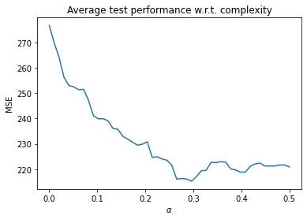

```python
plt.plot(ccp_alphas,-gsearch.cv_results_['mean_test_score'])
plt.xlabel(r'$\alpha$')
plt.ylabel('MSE')
plt.title('Average test performance w.r.t. complexity')
plt.show()
```

```python
cart_tree = DecisionTreeRegressor(random_state=0, ccp_alpha=0.3)
```

**Q27** Optimize Random Forest hyper-parameters, using a similar approach than previously. We will compare forests with 50, 100 and 200 trees, that has maximal depth ranging from 10 to 30

*Tips: find which parameters correspond to the number of trees in the RandomForestRegressor function, and which correspond to maximal depth, use arange from numpy to create a sequential list of integers between two bounds*

```python
%%time

model = RandomForestRegressor(random_state=0, max_features='sqrt')

param_search = {
    'n_estimators': [50, 100, 200],
    'max_depth' : np.arange(10,30)
}

gsearch = GridSearchCV(estimator=model, cv=tscv, param_grid=param_search, scoring = scorer)
gsearch.fit(X_train, Y_train)
```

```
CPU times: user 13min 53s, sys: 5.43 s, total: 13min 58s
Wall time: 14min 19s
```

```
GridSearchCV(cv=TimeSeriesSplit(gap=0, max_train_size=None, n_splits=8, test_size=None),
             estimator=RandomForestRegressor(max_features='sqrt',
                                             random_state=0),
             param_grid={'max_depth': array([10, 11, 12, 13, 14, 15, 16, 17, 18, 19, 20, 21, 22, 23, 24, 25, 26,
       27, 28, 29]),
                         'n_estimators': [50, 100, 200]},
             scoring=make_scorer(mean_squared_error, greater_is_better=False))
```

```python
gsearch.best_params_
```

```
{'max_depth': 16, 'n_estimators': 200}
```

```python
rf = gsearch.best_estimator_
```

```python
rf = RandomForestRegressor(random_state=0, max_features='sqrt',
                           max_depth = 16, n_estimators = 200)
```

## Evaluation of our 3 models

Back to table of contents.

**Q28** Using _cross_val_score_, print the averaged scores of each model. We have access to a variation of this score, since we have 8 evaluations. Displays also their boxplot!

*Tips: recall that we took the opposite of the MSE in the scorer*

```
LR: 144.641654 (64.709944)
CART: 215.646898 (75.100637)
RF: 137.611994 (50.593987)
```

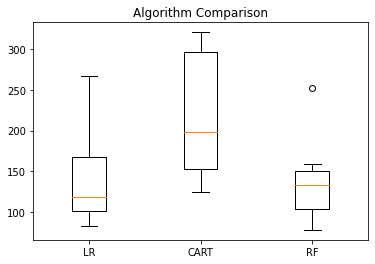

```python
models = []
models.append(('LR', LinearRegression()))
models.append(('CART', cart_tree))
models.append(('RF', rf))

# Evaluate each model in turn
results = []
names = []

for name, model in models:
    cv_results = cross_val_score(model, X_train, Y_train, cv=tscv, scoring=scorer)
    results.append(-cv_results)
    names.append(name)
    print('%s: %f (%f)' % (name, -cv_results.mean(), cv_results.std()))

# Compare Algorithms
plt.boxplot(results, labels=names)
plt.title('Algorithm Comparison')
plt.show()
```

## Forecast last semester

Back to table of contents.

We can now try to forecast last semester of 2019!

**Q29** As for the training, define X_test and Y_test.

```python
X_test = data_test.iloc[:,2:data_test.shape[1]]
Y_test = data_test.loc[:,'FR_SpotPrice']
```

The values of the RMSE and the MAE does are not enough to quantify the performances of our algorithm. We need to relate to a baseline/naive model.

**Q30** Which naive predictor do you propose? Implement it!

```python
naive_pred = Y_test.shift(24)
naive_pred[0:24] = Y_train.tail(24)
```

**Q31** Fit our 3 models on the training data, and predict on the testing one.

```python
cart_tree.fit(X_train, Y_train)
rf.fit(X_train, Y_train)
```

```
RandomForestRegressor(max_depth=16, max_features='sqrt', n_estimators=200,
                      random_state=0)
```

```python
lr = LinearRegression()
lr.fit(X_train, Y_train)
```

```
LinearRegression()
```

```python
cart_pred = cart_tree.predict(X_test)
rf_pred = rf.predict(X_test)
lr_pred = lr.predict(X_test)
```

**Q32** Print and compare the performances of the predictions.

_Tips: use our custom function regression_results_

```python
print('Naive predictor')
regression_results(Y_test, naive_pred)
print('--------------')
print('Linear regression')
regression_results(Y_test, lr_pred)
print('--------------')
print('CART tree')
regression_results(Y_test, cart_pred)
print('--------------')
print('Random forest')
regression_results(Y_test, rf_pred)
```

```
Naive predictor
r2:  0.4836
MAE:  6.4115
RMSE:  8.8177
--------------
Linear regression
r2:  0.4386
MAE:  7.2209
RMSE:  9.194
--------------
CART tree
r2:  -0.651
MAE:  12.8129
RMSE:  15.767
--------------
Random forest
r2:  0.2833
MAE:  8.2078
RMSE:  10.388
```

Our predictions are worse than the naive predictor, we can do better! But first, let's analyze better our models.

**Q33** Plot the realized prices and our predictions for the first week of our test data. Add a legend.

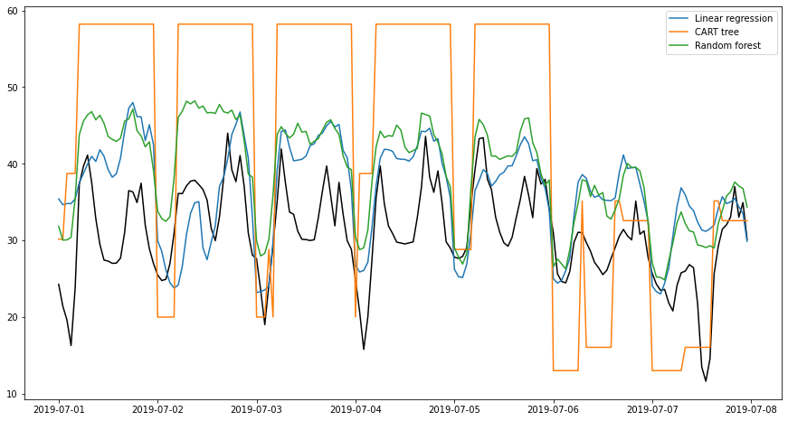

```python
fig, ax = plt.subplots(figsize=(15,8))
ax.plot(data_test.date[0:24*7], data_test.FR_SpotPrice[0:24*7], color='black')
ax.plot(data_test.date[0:24*7], lr_pred[0:24*7], label="Linear regression")
ax.plot(data_test.date[0:24*7], cart_pred[0:24*7], label="CART tree")
ax.plot(data_test.date[0:24*7], rf_pred[0:24*7], label="Random forest")
ax.legend()
plt.show()
```

Analyzing our forest. What is **feature importance**?

Feature importance assigns a score of input features based on their influence to predict the target.  
The more the features will be "responsible" to predict the target the greater will be their score. Feature importance allows a better interpretability of the variables and the forest (indeed, how can we interpret an averaged of 200 trees?). Several approach to compute these scores are proposed in the litterature, depending on the chosen models.

Mean Decrease Impurity (MDI) is one of the variable importance measures in random forests. Few theoretical justifications to use MDI are available. In particular, a paper (Scornet (2021)) analyzes MDI and proves that if input variables are independent and in absence of interactions, MDI provides a variance decomposition of the output, where the contribution of each variable is clearly identified.

https://scikit-learn.org/stable/auto_examples/inspection/plot_permutation_importance.html  
[Scornet (2021)](https://arxiv.org/pdf/2001.04295.pdf)  
[Genuer, Poggi and Tuleau (2008)](https://arxiv.org/abs/0811.3619)  
[Genuer, Poggi and Tuleau (2010)](https://hal.archives-ouvertes.fr/hal-00755489/document)

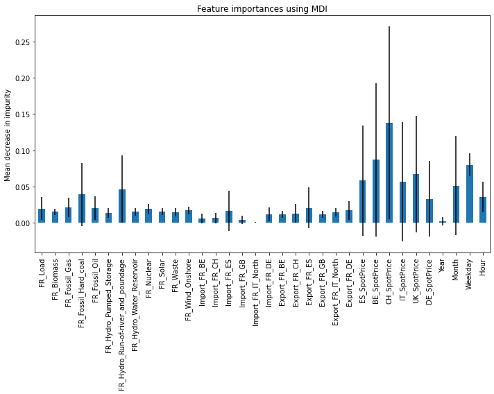

```python
importances = rf.feature_importances_
std = np.std([tree.feature_importances_ for tree in rf.estimators_], axis=0)

forest_importances = pd.Series(importances, index=data_train.iloc[:,2:data_train.shape[1]].columns)

fig, ax = plt.subplots(figsize=(10,8))
forest_importances.plot.bar(yerr=std, ax=ax)
ax.set_title("Feature importances using MDI")
ax.set_ylabel("Mean decrease in impurity")
fig.tight_layout()
```

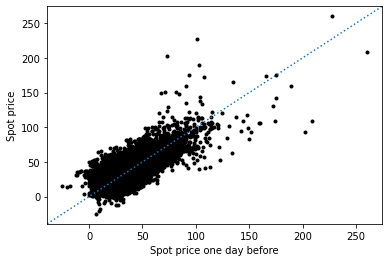

```python
fig, ax = plt.subplots()
ax.scatter(data_train.FR_SpotPrice.shift(24), data_train.FR_SpotPrice, marker='.', color='black')
ax.set_ylabel("Spot price")
ax.set_xlabel("Spot price one day before")
ax.plot([0,1],[0,1], transform=ax.transAxes, linestyle=':')
plt.show()
```

# Adding useful features!

Back to table of contents.

**Q34** Given than the naive predictor is better than us, what could you suggest?

## Lagged price

**Q35** Create this new feature and add it.

```python
data['SpotPrice_Lagged'] = data.FR_SpotPrice.shift(24)
```

**Q36** Recreate the training and test set with this added feature. What do you have to be careful at?

```python
data_train = data.loc[data.date <= limit_train,:]
data_train = data_train.drop(np.arange(48), axis=0) ## Initials NA because of lagged variables
data_test = data.loc[(data.date > limit_train) & (data.date <= limit_test),:]
X_train = data_train.iloc[:,2:data_train.shape[1]]
Y_train = data_train.loc[:,'FR_SpotPrice']
X_test = data_test.iloc[:,2:data_test.shape[1]]
Y_test = data_test.loc[:,'FR_SpotPrice']
```

**Q37** Fit again the models, predict and analyze.

*NB: we should re-do the optimization of the hyper-parameters for the tree and the forest. Because of their computational time, we do not do it here, and keep the previous models*

```python
lr = LinearRegression()
lr.fit(X_train, Y_train)
cart_tree.fit(X_train, Y_train)
rf.fit(X_train, Y_train)
```

```
RandomForestRegressor(max_depth=16, max_features='sqrt', n_estimators=200,
                      random_state=0)
```

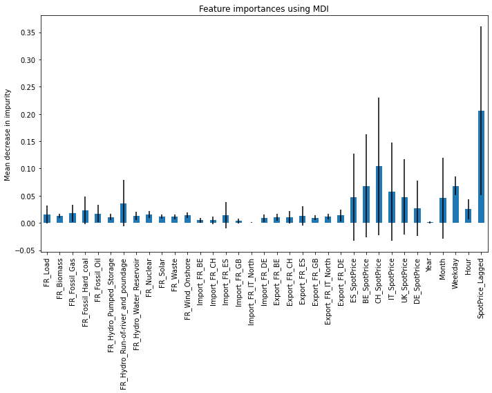

```python
importances = rf.feature_importances_
std = np.std([tree.feature_importances_ for tree in rf.estimators_], axis=0)

forest_importances = pd.Series(importances, index=data_train.iloc[:,2:data_train.shape[1]].columns)

fig, ax = plt.subplots(figsize=(10,8))
forest_importances.plot.bar(yerr=std, ax=ax)
ax.set_title("Feature importances using MDI")
ax.set_ylabel("Mean decrease in impurity")
fig.tight_layout()
```

```python
cart_pred = cart_tree.predict(X_test)
rf_pred = rf.predict(X_test)
lr_pred = lr.predict(X_test)
```

```python
print('Naive predictor')
regression_results(Y_test, naive_pred)
print('--------------')
print('Linear regression')
regression_results(Y_test, lr_pred)
print('--------------')
print('CART tree')
regression_results(Y_test, cart_pred)
print('--------------')
print('Random forest')
regression_results(Y_test, rf_pred)
```

```
Naive predictor
r2:  0.4836
MAE:  6.4115
RMSE:  8.8177
--------------
Linear regression
r2:  0.6444
MAE:  5.7236
RMSE:  7.3169
--------------
CART tree
r2:  -0.2432
MAE:  10.133
RMSE:  13.6818
--------------
Random forest
r2:  0.5045
MAE:  6.6713
RMSE:  8.638
```

## Lagged price w.r.t. weekdays/weekends

**Q38** It is better, but do you think our lags make sense given the weekly pattern of our data? Improve the lags! And redo all the analysis.

```python
SpotPrice_Lagged_1Week = data.FR_SpotPrice.shift(168)
data['SpotPrice_Lagged'] = SpotPrice_Lagged_1Week.where(np.isin(data.Weekday, [0,5,6]), other=data.SpotPrice_Lagged)
```

```python
data_train = data.loc[data.date <= limit_train,:]
data_train = data_train.drop(np.arange(168), axis=0) ## Initials NA because of lagged variables
data_test = data.loc[(data.date > limit_train) & (data.date <= limit_test),:]
X_train = data_train.iloc[:,2:data_train.shape[1]]
Y_train = data_train.loc[:,'FR_SpotPrice']
X_test = data_test.iloc[:,2:data_test.shape[1]]
Y_test = data_test.loc[:,'FR_SpotPrice']
```

```python
lr = LinearRegression()
lr.fit(X_train, Y_train)
cart_tree.fit(X_train, Y_train)
rf.fit(X_train, Y_train)
```

```
RandomForestRegressor(max_depth=16, max_features='sqrt', n_estimators=200,
                      random_state=0)
```

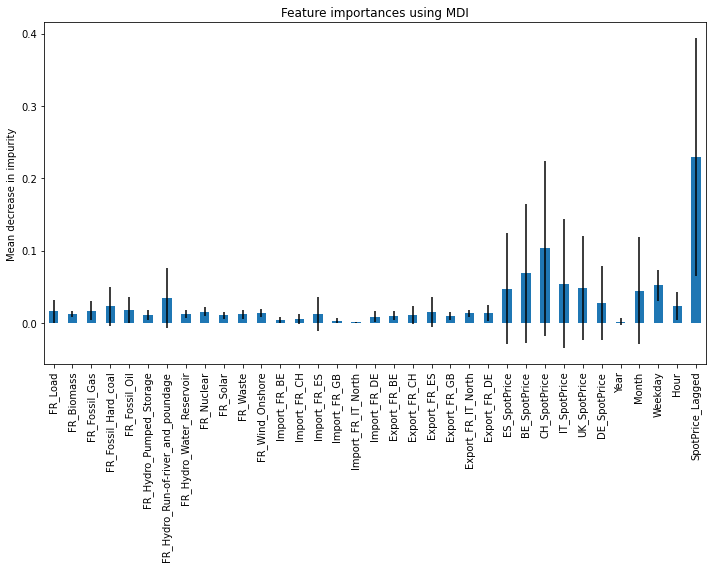

```python
importances = rf.feature_importances_
std = np.std([tree.feature_importances_ for tree in rf.estimators_], axis=0)

forest_importances = pd.Series(importances, index=data_train.iloc[:,2:data_train.shape[1]].columns)

fig, ax = plt.subplots(figsize=(10,8))
forest_importances.plot.bar(yerr=std, ax=ax)
ax.set_title("Feature importances using MDI")
ax.set_ylabel("Mean decrease in impurity")
fig.tight_layout()
```

```python
cart_pred = cart_tree.predict(X_test)
rf_pred = rf.predict(X_test)
lr_pred = lr.predict(X_test)
```

```python
print('Naive predictor')
regression_results(Y_test, naive_pred)
print('--------------')
print('Linear regression')
regression_results(Y_test, lr_pred)
print('--------------')
print('CART tree')
regression_results(Y_test, cart_pred)
print('--------------')
print('Random forest')
regression_results(Y_test, rf_pred)
```

```
Naive predictor
r2:  0.4836
MAE:  6.4115
RMSE:  8.8177
--------------
Linear regression
r2:  0.6496
MAE:  5.581
RMSE:  7.2641
--------------
CART tree
r2:  0.5391
MAE:  6.0728
RMSE:  8.331
--------------
Random forest
r2:  0.5868
MAE:  5.9887
RMSE:  7.8879
```

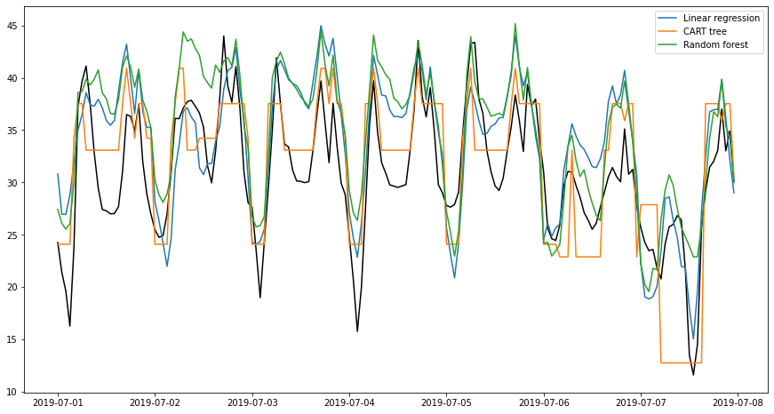

```python
fig, ax = plt.subplots(figsize=(15,8))
ax.plot(data_test.date[0:24*7], data_test.FR_SpotPrice[0:24*7], color='black')
ax.plot(data_test.date[0:24*7], lr_pred[0:24*7], label="Linear regression")
ax.plot(data_test.date[0:24*7], cart_pred[0:24*7], label="CART tree")
ax.plot(data_test.date[0:24*7], rf_pred[0:24*7], label="Random forest")
ax.legend()
plt.show()
```

We have assessed their performance predictions, but not the shape of their errors. This should always be done before any forecast (that is, again, using cross validation): if your errors still contain dependency, or are not zero-centered (among other things) this is highly problematic!

**Q39** Get the residuals ($y_t - \hat{y}_t$) of the cross-validation.

*Tips: we can not use any built-in method from sklearn. Code your loop, using the tscv object previously created*

```python
lr_pred_cv = np.full(len(Y_train), np.nan)

for train_idx, test_idx in tscv.split(X_train):

    #get subsets of variables from CV
    X_train_lr_k, X_test_k = X_train.iloc[train_idx], X_train.iloc[test_idx]
    Y_train_lr_k = Y_train.iloc[train_idx]

    #fit model
    lr = LinearRegression()
    lr.fit(X_train_lr_k, Y_train_lr_k)
    pred_vals = lr.predict(X_test_k)

    #store predicted values
    lr_pred_cv[test_idx] = pred_vals
```

```python
nb_na = len(Y_train) // 9 + len(Y_train) % 9
Y_train_wo_na = Y_train[nb_na:]
```

```python
lr_pred_cv = lr_pred_cv[nb_na:]
```

```python
res_lr_cv = Y_train_wo_na - lr_pred_cv
```

```python
3 * len(Y_train) // 9
```

```
4312
```

```python
6*30*24
```

```
4320
```

**Q40** Plot these residuals. What do you observe? Can you explain it?

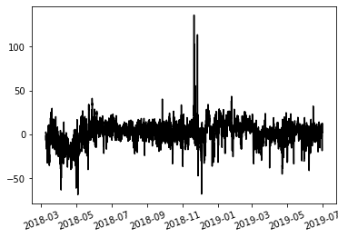

```python
plt.plot(data_train.date[nb_na : ], res_lr_cv, color='black')
plt.tick_params(axis='x', rotation=20)
plt.show()
```

```python
res_lr_cv_warmup = res_lr_cv[3 * len(Y_train) // 9 - nb_na : ]
```

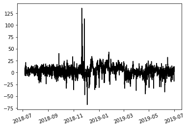

```python
plt.plot(data_train.date[3 * len(Y_train) // 9 : ], res_lr_cv_warmup, color='black')
plt.tick_params(axis='x', rotation=20)
plt.show()
```

**Q41** Display their histogram.

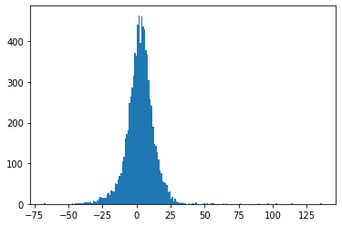

```python
plt.hist(res_lr_cv_warmup, bins=200)
plt.show()
```

Autocorrelation and Partial Auto-Correlation functions allow to analyse the correlation of a serie to its past.

**Q42** Using _plot_acf_, _plot_pacf_ from statsmodels.graphics.tsaplots, show their autocorrelations. What do you observe? Do you expect it?

```python
from statsmodels.graphics.tsaplots import plot_acf, plot_pacf
```

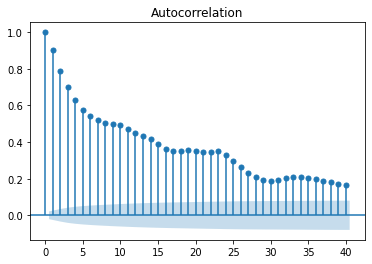

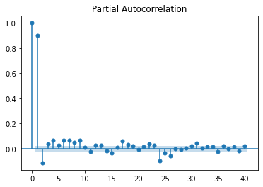

```python
plot_acf(res_lr_cv_warmup)
plt.show()
plot_pacf(res_lr_cv_warmup)
plt.show()
```

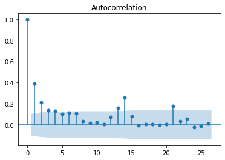

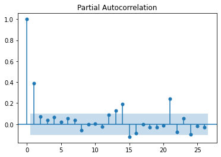

```python
i = 8
plot_acf(res_lr_cv_warmup[i::24])
plt.show()
plot_pacf(res_lr_cv_warmup[i::24])
plt.show()
```

Note here that this should *absolutely* be done for our 3 models. For time considerations, we only do it for the linear regression here.

```python
lr = LinearRegression()
lr.fit(X_train, Y_train)
cart_tree.fit(X_train, Y_train)
rf.fit(X_train, Y_train)
```

```
RandomForestRegressor(max_depth=16, max_features='sqrt', n_estimators=200,
                      random_state=0)
```

```python
cart_pred = cart_tree.predict(X_test)
rf_pred = rf.predict(X_test)
lr_pred = lr.predict(X_test)
```

```python
print('Naive predictor')
regression_results(Y_test, naive_pred)
print('--------------')
print('Linear regression')
regression_results(Y_test, lr_pred)
print('--------------')
print('CART tree')
regression_results(Y_test, cart_pred)
print('--------------')
print('Random forest')
regression_results(Y_test, rf_pred)
```

```
Naive predictor
r2:  0.4836
MAE:  6.4115
RMSE:  8.8177
--------------
Linear regression
r2:  0.6496
MAE:  5.581
RMSE:  7.2641
--------------
CART tree
r2:  0.5391
MAE:  6.0728
RMSE:  8.331
--------------
Random forest
r2:  0.5868
MAE:  5.9887
RMSE:  7.8879
```

# Can we forecast 2020? 2021?

Back to table of contents.

Now that we have selected our models and assessed that their errors are approximately acceptable, we can try to forecast more difficult periods: 2020 with the quarantine, and 2021 with th price explosion in Fall.

## 2020

Let's start with 2020.

**Q43** Redefine the training and testing data sets: training end at 2019-12-31 23 and testing at 2020-12-31 23.

```python
limit_train = datetime.strptime('2019-12-31 23:00:00', "%Y-%m-%d %H:%M:%S")
limit_test = datetime.strptime('2020-12-31 23:00:00', "%Y-%m-%d %H:%M:%S")
data_train = data.loc[data.date <= limit_train,:]
data_test = data.loc[(data.date > limit_train) & (data.date <= limit_test),:]
```

```python
data_train = data.loc[data.date <= limit_train,:]
data_train = data_train.drop(np.arange(168), axis=0) ## Initials NA because of lagged variables
data_test = data.loc[(data.date > limit_train) & (data.date <= limit_test),:]
X_train = data_train.iloc[:,2:data_train.shape[1]]
Y_train = data_train.loc[:,'FR_SpotPrice']
X_test = data_test.iloc[:,2:data_test.shape[1]]
Y_test = data_test.loc[:,'FR_SpotPrice']
```

**Q44** Regenerate the dumb predictor.

```python
naive_pred = Y_test.shift(24)
naive_pred[0:24] = Y_train.tail(24)
```

**Q45** And let's go! Fit, predict and compare. What can you say?

```python
lr = LinearRegression()
lr.fit(X_train, Y_train)
cart_tree.fit(X_train, Y_train)
rf.fit(X_train, Y_train)
```

```
RandomForestRegressor(max_depth=16, max_features='sqrt', n_estimators=200,
                      random_state=0)
```

```python
cart_pred = cart_tree.predict(X_test)
rf_pred = rf.predict(X_test)
lr_pred = lr.predict(X_test)
```

```python
print('Naive predictor')
regression_results(Y_test, naive_pred)
print('--------------')
print('Linear regression')
regression_results(Y_test, lr_pred)
print('--------------')
print('CART tree')
regression_results(Y_test, cart_pred)
print('--------------')
print('Random forest')
regression_results(Y_test, rf_pred)
```

```
Naive predictor
r2:  0.5764
MAE:  6.8755
RMSE:  10.4832
--------------
Linear regression
r2:  0.7311
MAE:  5.9382
RMSE:  8.3522
--------------
CART tree
r2:  0.6044
MAE:  7.1114
RMSE:  10.131
--------------
Random forest
r2:  0.5915
MAE:  7.2138
RMSE:  10.2944
```

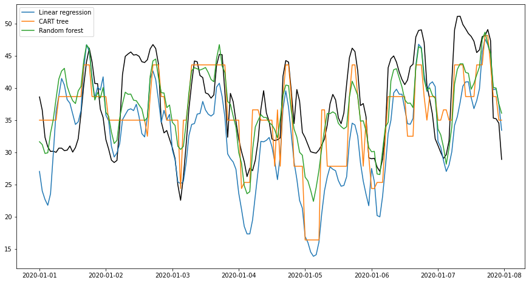

```python
fig, ax = plt.subplots(figsize=(15,8))
ax.plot(data_test.date[0:24*7], data_test.FR_SpotPrice[0:24*7], color='black')
ax.plot(data_test.date[0:24*7], lr_pred[0:24*7], label="Linear regression")
ax.plot(data_test.date[0:24*7], cart_pred[0:24*7], label="CART tree")
ax.plot(data_test.date[0:24*7], rf_pred[0:24*7], label="Random forest")
ax.legend()
plt.show()
```

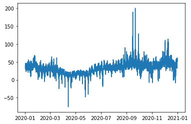

```python
plt.plot(data_test.date, data_test.FR_SpotPrice)
plt.show()
```

The errors are deteriorated, but not that much, and still better than the naive. In practice, we should dive into what happens in March and April, with the huge negative prices. If you are interested, you can do this job and try to improve your model :) In class, we will jump onto 2021, which is also super interesting!